# Final project

2023-12-15

# Question a

```r
loans <- read.csv("/Users/sanskriti/Desktop/DATA-180-Sanskriti/loan_default_data_set.csv")
dim(loans)
```

```
## [1] 20000    21
```

This data set has 20000 rows and 21 columns.

# Question b

```r
column_names <- names(loans)
print(column_names)
```

```
##  [1] "tot_balance"                     "avg_bal_cards"
##  [3] "credit_age"                      "credit_age_good_account"
##  [5] "credit_card_age"                 "num_acc_30d_past_due_12_months"
##  [7] "num_acc_30d_past_due_6_months"   "num_mortgage_currently_past_due"
##  [9] "tot_amount_currently_past_due"   "num_inq_12_month"
## [11] "num_card_inq_24_month"           "num_card_12_month"
## [13] "num_auto_.36_month"              "uti_open_card"
## [15] "pct_over_50_uti"                 "uti_max_credit_line"
## [17] "pct_card_over_50_uti"            "ind_XYZ"
## [19] "rep_income"                      "rep_education"
## [21] "Def_ind"
```

# Question c

This data set has mostly numeric data except for column ‘rep_education’ which has ordinal data and ‘def_ind’ and ‘ind_XYZ’ which has categorical data.

# Question d

```r
colnames(loans)[colSums(is.na(loans)) > 0]
```

```
## [1] "pct_card_over_50_uti" "rep_income"
```

```r
Missing <- colnames(loans)[colSums(is.na(loans)) > 0]
percent_missing <- (colSums(is.na(loans[, Missing])) / nrow(loans)) * 100
percent_missing
```

```
## pct_card_over_50_uti           rep_income
##                9.790                7.795
```

# Question e

Some of the many ways to fix the missing values would be to remove the rows or columns which contains missing data. In this data set, it would be most suitable to remove the few rows that have missing data. However, in case of data sets were there are many rows missing, we could delete the whole column. Another way would be to be to create a new category for missing values.

# Question f

This data fits the supervised learning model as it has a response variable Def_Ind which is an indicator of default. Likewise, this data also predicts whether the applicant’s attributes are derived from information obtained bu bank XYZ at the time of application. As the dats is making predictions and uses a response variable, supervised learning model would be best fit for this data.

# Question g

```r
remove_missing <- na.omit(loans)
dim(remove_missing)
```

```
## [1] 16653    21
```

# Part 2

# Question a

```r
library(dplyr)
summaryStats <- summary(remove_missing)
print(summaryStats)
```

```
##   tot_balance     avg_bal_cards     credit_age    credit_age_good_account
##  Min.   :     0   Min.   :    0   Min.   :  0.0   Min.   :  0.0
##  1st Qu.: 92142   1st Qu.:10135   1st Qu.:231.0   1st Qu.:120.0
##  Median :107740   Median :12237   Median :281.0   Median :146.0
##  Mean   :107503   Mean   :12226   Mean   :280.9   Mean   :146.2
##  3rd Qu.:122932   3rd Qu.:14297   3rd Qu.:330.0   3rd Qu.:172.0
##  Max.   :200000   Max.   :25000   Max.   :550.0   Max.   :300.0
##  credit_card_age num_acc_30d_past_due_12_months num_acc_30d_past_due_6_months
##  Min.   :  0.0   Min.   :0.0000                 Min.   :0.00000
##  1st Qu.:242.0   1st Qu.:0.0000                 1st Qu.:0.00000
##  Median :285.0   Median :0.0000                 Median :0.00000
##  Mean   :285.4   Mean   :0.1579                 Mean   :0.02936
##  3rd Qu.:330.0   3rd Qu.:0.0000                 3rd Qu.:0.00000
##  Max.   :550.0   Max.   :5.0000                 Max.   :2.00000
##  num_mortgage_currently_past_due tot_amount_currently_past_due
##  Min.   :0.0000                  Min.   :    0.0
##  1st Qu.:0.0000                  1st Qu.:    0.0
##  Median :0.0000                  Median :    0.0
##  Mean   :0.0299                  Mean   :  354.2
##  3rd Qu.:0.0000                  3rd Qu.:    0.0
##  Max.   :1.0000                  Max.   :35000.0
##  num_inq_12_month  num_card_inq_24_month num_card_12_month num_auto_.36_month
##  Min.   : 0.0000   Min.   : 0.000        Min.   :0.0000    Min.   :0.000
##  1st Qu.: 0.0000   1st Qu.: 0.000        1st Qu.:0.0000    1st Qu.:0.000
##  Median : 0.0000   Median : 0.000        Median :0.0000    Median :0.000
##  Mean   : 0.6133   Mean   : 1.044        Mean   :0.2723    Mean   :0.165
##  3rd Qu.: 1.0000   3rd Qu.: 1.000        3rd Qu.:1.0000    3rd Qu.:0.000
##  Max.   :10.0000   Max.   :18.000        Max.   :3.0000    Max.   :2.000
##  uti_open_card    pct_over_50_uti  uti_max_credit_line pct_card_over_50_uti
##  Min.   :0.0000   Min.   :0.0000   Min.   :0.0000      Min.   :0.0000
##  1st Qu.:0.4048   1st Qu.:0.4011   1st Qu.:0.3778      1st Qu.:0.4643
##  Median :0.4909   Median :0.4855   Median :0.4649      Median :0.5518
##  Mean   :0.4914   Mean   :0.4842   Mean   :0.4653      Mean   :0.5511
##  3rd Qu.:0.5783   3rd Qu.:0.5679   3rd Qu.:0.5541      3rd Qu.:0.6384
##  Max.   :1.0000   Max.   :0.9294   Max.   :1.0000      Max.   :1.0000
##     ind_XYZ         rep_income     rep_education         Def_ind
##  Min.   :0.0000   Min.   : 20000   Length:16653       Min.   :0.0000
##  1st Qu.:0.0000   1st Qu.:143751   Class :character   1st Qu.:0.0000
##  Median :0.0000   Median :166630   Mode  :character   Median :0.0000
##  Mean   :0.2487   Mean   :166504                      Mean   :0.1019
##  3rd Qu.:0.0000   3rd Qu.:189020                      3rd Qu.:0.0000
##  Max.   :1.0000   Max.   :300000                      Max.   :1.0000
```

# Question b

For num_card_inq_24_month since the mean(1.044) is greater than the median (0) , it is skewed to the right. For total_amount_currently_past_due, the mean(354.2) is heavily greater than the median(0). As a result it is also skeewed to the right. For credit_age, since the mean(280.9) and median(281) are close in value , it is approximately bell shaped

# Question c

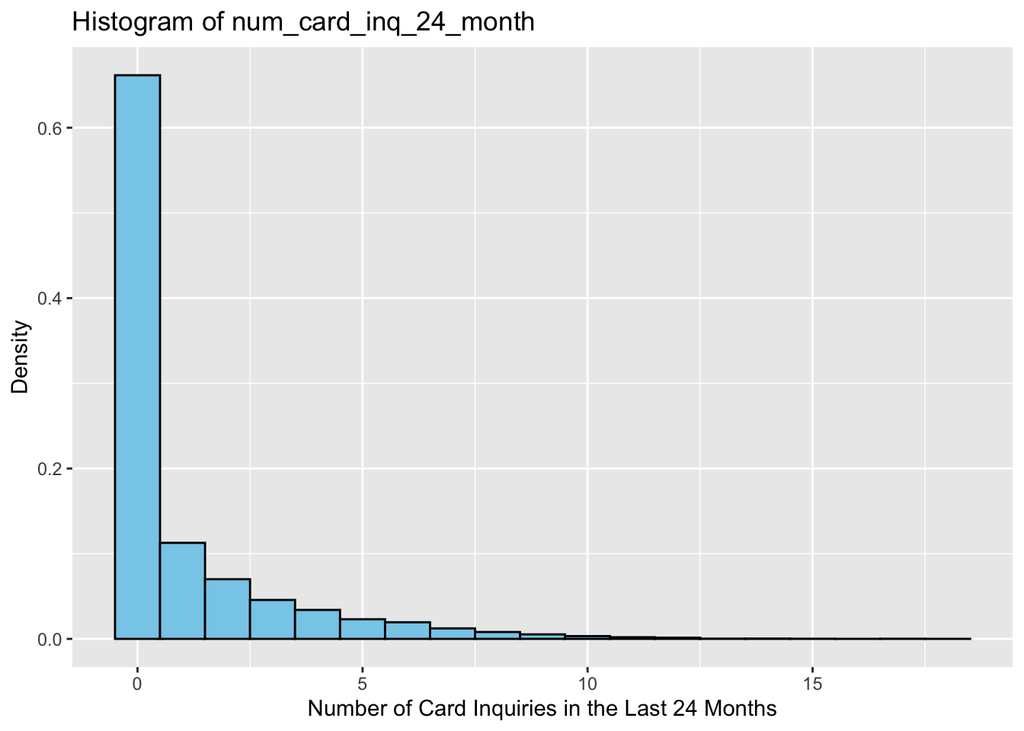

```r
library(ggplot2)
ggplot(data = remove_missing, aes(x = num_card_inq_24_month)) +
  geom_histogram(binwidth = 1, fill = "skyblue", color = "black", aes(y = after_stat(density))) +
  ggtitle("Histogram of num_card_inq_24_month") +
  xlab("Number of Card Inquiries in the Last 24 Months") +
  ylab("Density")
```

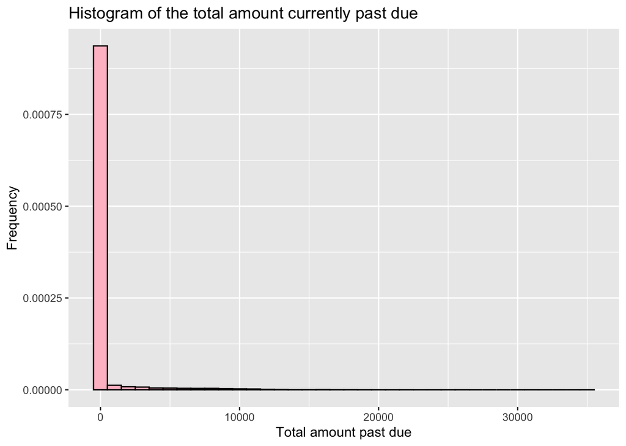

```r
ggplot(data = remove_missing, aes(x = tot_amount_currently_past_due)) +
  geom_histogram(binwidth = 1000, fill = "pink", color = "black", aes(y = after_stat(density))) +
  ggtitle("Histogram of the total amount currently past due") +
  xlab("Total amount past due") + ylab("Frequency")
```

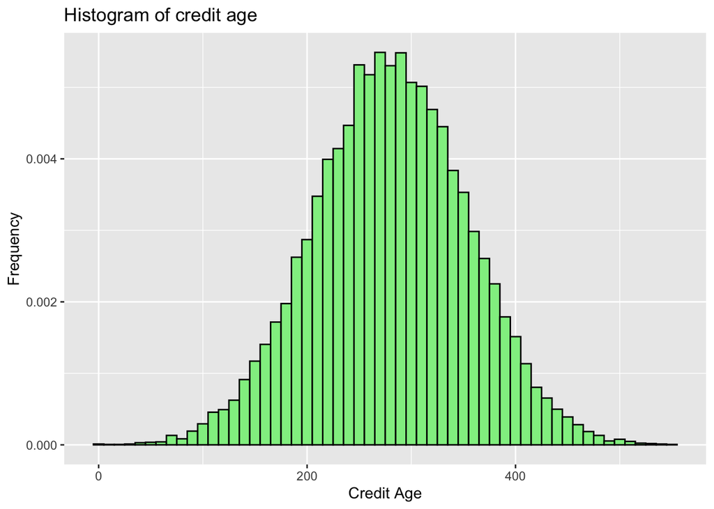

```r
ggplot(data = remove_missing, aes(x = credit_age)) +
  geom_histogram(binwidth = 10, fill = "lightgreen", color = "black", aes(y = after_stat(density))) +
  ggtitle("Histogram of credit age") +
  xlab("Credit Age") + ylab("Frequency")
```

Similar to our calculations before, we can see from these histograms that num_card_inq_24_month and tot_amount_currently_past_due are both skewed to the right and credit_age is bell-shaped.

# Question d

One way to convert rep_education into numerical data is by label encoding where you assign a numerical value to each category. Since there are four ordinal categories in rep_education each categoru could get an unique value such as high school = 1, college = 2, graduate = 3, others = 3. Another way is by one-hot enocoding which creates binary columns for each category.

# Part 3

#Question a

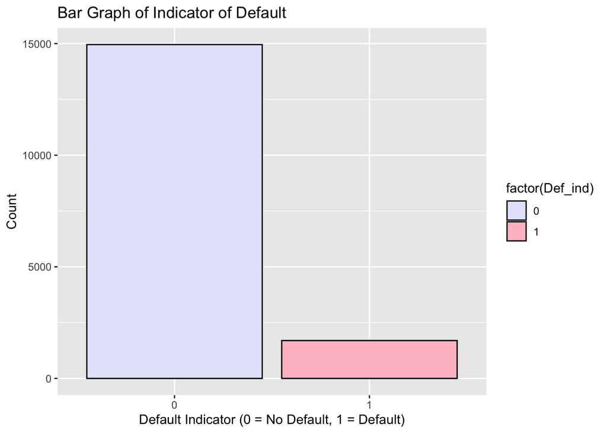

```r
library(ggplot2)

ggplot(data = remove_missing, aes(x = factor(Def_ind), fill = factor(Def_ind))) +
  geom_bar(color = "black",  linewidth=0.5) +
  scale_fill_manual(values = c("lavender", "pink")) +
  ggtitle("Bar Graph of Indicator of Default") +
  xlab("Default Indicator (0 = No Default, 1 = Default)") +
  ylab("Count")
```

The variable Def-ind is an indicator of default with binary value 1 being account defaulted after an account was approved and opened with bank XYZ in the past 18 months while 0 being not defaulted. The x axis shows the binary values 0 and 1, while the y axis shows their count. As we can see from the bar graph, around 15000 people have not defaulted their accounts while only less than 2500 people have defaulted their accounts.

# Question b

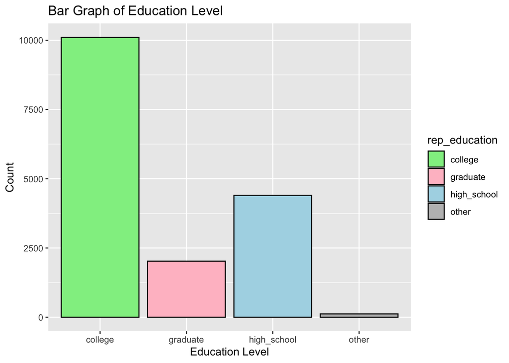

```r
library(ggplot2)

ggplot(data = remove_missing, aes(x = rep_education, fill = rep_education)) +
  geom_bar(color = "black",  linewidth=0.5) +
  scale_fill_manual(values = c("lightgreen", "pink", "lightblue", "gray")) +
  ggtitle("Bar Graph of Education Level") +
  xlab("Education Level") +
  ylab("Count")
```

This bar graph shows the education levels the applicants in the data set. The x-axis has four categories for education levels which are college, graduate, high school and other. While the y axis gives us the count of people for each level of education. We can see that most people have an education of college degree with a count alightly above 10000. Second highest is a high school degree with a count less than 5000. Third highest is graduate degree with a count less than 2500 and last is other education level with a count of approximately 200.

#Question c

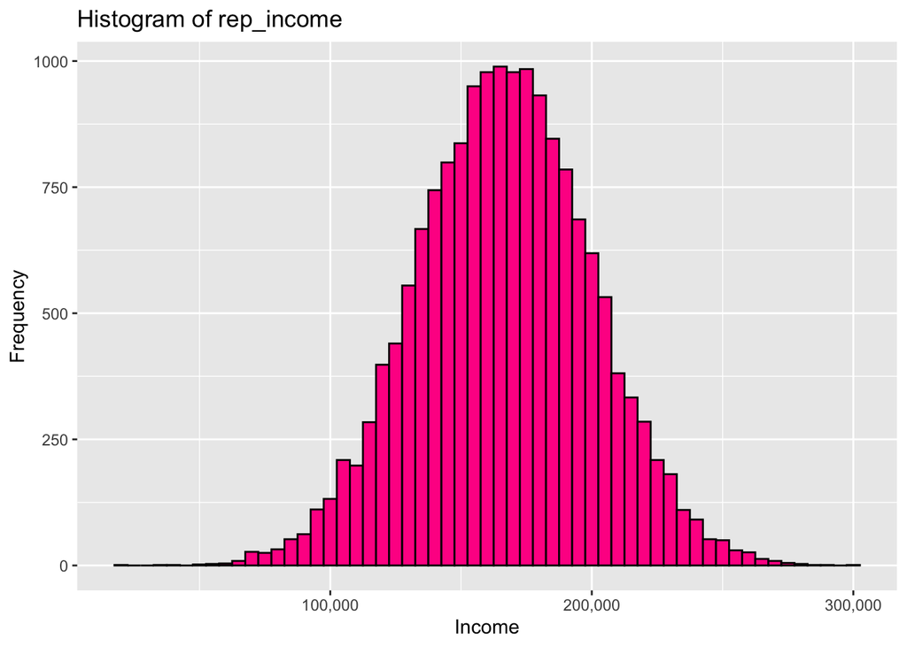

```r
library(ggplot2)

ggplot(data = remove_missing, aes(x = rep_income, fill = factor(rep_income))) +
  geom_histogram(color = "black", fill = "deeppink", binwidth = 5000) +
  ggtitle("Histogram of rep_income") +
  xlab("Income") +
  ylab("Frequency") +
  scale_x_continuous(labels = scales::comma_format())
```

# Question d

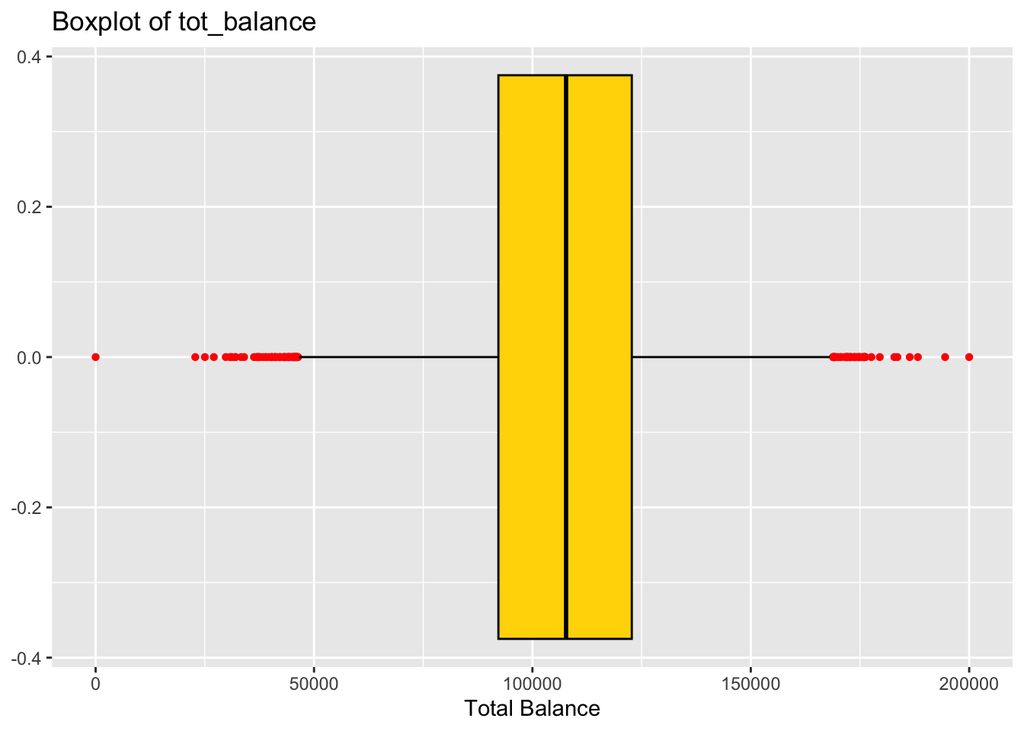

```r
library(ggplot2)


ggplot(data = loans, aes(x = tot_balance)) +
  geom_boxplot(color = "black", fill = "gold", outlier.colour = "red", outlier.shape = 16) +
  ggtitle("Boxplot of tot_balance") +
  xlab("Total Balance")
```

```r
#Actual 5 number theory for check
summary(remove_missing$tot_balance)
```

```
##    Min. 1st Qu.  Median    Mean 3rd Qu.    Max.
##       0   92142  107740  107503  122932  200000
```

min- 0

3rd Q - 125000

max- 200000

There are many outliers which we can observe in the boxplot in the color red.